# Demo 1: Biomedical & Clinical Informatics

Merrimack College DSE6630: Healthcare & Life Sciences Analytics

Vicky（Xin) Guo

13 May 2026

# Introduction

You have just been brought on as a data science consultant for a patient advocacy watchdog. They have asked you to source information about hospital readmissions, because they would like to flag specific geographic areas or types of hospitals where hospital readmission is unexpectedly high. They have heard that datasets exist to investigate these types of questions, but they are not really sure where to begin.

You remember this one data science class you took - and the dataset from the **Centers for Medicare & Medicaid Services** managed by [Medicare.gov](https://www.medicare.gov). You start poking around the [Hospitals](https://data.cms.gov/provider-data/topics/hospitals) dataset and decide it is exactly what you need.

The problem is, this dataset is massive, so you are not only tasked with identifying a reasonable question you can ask from the dataset but managing the cleaning, pre-processing, and exploratory data analysis on the merged datasets you choose to explore.

## Question

For **Project 1**, you are going to choose your own question! But for this demo analysis, we are focusing on **pneumonia-related hospital readmissions**.

### Why pneumonia-related readmissions?

Hospital readmission rates for patients with pneumonia is almost unbelievably high, with about $\frac{1}{5}$ or 20% of patients hospitalized with pneumonia re-admitted within 30 days (de Alba and Amin, 2014). Further, pneumonia is both a leading cause of death among the elderly as well as a commonly communicated disease in hospitals (as in, people may come into a hospital for a different condition but be readmitted for pneumonia). Thus, given that pneumonia is the only communicable disease on this list, it is serving as our best proxy for diseases spread person-to-person within hospitals because of lack of availability.

#### Our research question:

Can we predict pneumonia-related hospital readmissions and, more generally, disease transfer within hospitals, based on hospital-level characteristics, including patient-ratings, Medicare money received, and other indicators of general performance in disease diagnosis and prevention?

#### Our hypothesis & prediction:

Hospitals are, by their very nature, hot zones for increased spread of disease, including pneumonia. We hypothesize that hospitals with lower indicators of patient care performance and lower Medicare funding rates will generally be unable to provide sufficient control of specific disease diagnosis and prevention, like pneumonia. This is because the same intrinsic and extrinsic factors that impact general patient quality of care is likely to extend to pneumonia, a *common, preventable, and treatable* disease. Thus, we specifically predict that factors indicating lower quality-of-care will predict higher than average rates of pneumonia-related hospital readmissions.

## Objective

Our objective for the patient advocacy watchdog is clean, merge, explore, and predict which hospitals tend to have higher-than-average rates of pneumonia-related readmissions. This is to enable the watchdog group to put together a dashboard or otherwise deploy this information to share with patients so they know how their local hospitals are performing, allowing them to make healthier, more informed choices.

# Data & Data Cleaning

1. Download the [Hospitals](https://data.cms.gov/provider-data/topics/hospitals) dataset as a zip directory.
2. Unzip the directory.
3. Make sure to adjust the name and/or path of the directory in your directory if it is different from mine. *Note that mine is living on my Desktop.*

**WARNING!** Do not try to put these data onto GitHub. They are too large to push. If you need help adjusting your path or have questions, please let me know.

```r
## Make sure to adjust your path!
filepath <- "~/Development/R_workspaces/hospitals_current_data/"

dir.exists(filepath)
```

```
## [1] TRUE
```

```r
# What's actually in the folder?
list.files(filepath)
```

```
##  [1] "ASC_Facility.csv"
##  [2] "ASC_National.csv"
##  [3] "ASC_State.csv"
##  [4] "ASCQR_OAS_CAHPS_BY_ASC.csv"
##  [5] "ASCQR_OAS_CAHPS_NATIONAL.csv"
##  [6] "ASCQR_OAS_CAHPS_STATE.csv"
##  [7] "Birthing_Friendly_Hospitals_Geocoded.csv"
##  [8] "CJR_Quality_Reporting_January_2026_Production_File.csv"
##  [9] "CMS_PSI_6_decimal_file.csv"
## [10] "Complications_and_Deaths-Hospital.csv"
## [11] "Complications_and_Deaths-National.csv"
## [12] "Complications_and_Deaths-State.csv"
## [13] "Data_Updates_April_2026.csv"
## [14] "Footnote_Crosswalk.csv"
## [15] "FY_2026_HAC_Reduction_Program_Hospital.csv"
```

[output cut: 60 more lines]

### Read in the hospital-level data iteratively, while dynamically naming & storing each file as a dataframe.

You may have to dig through the accompanying data dictionary **HOSPITAL_Data_Dictionary.pdf** to get a better handle on what is in the hospital-level files.

##### **Question 1**: [1 point]

Take a look at the chunk below, which performs **dynamic variable assignment** as it reads in each of the files. Your task is to add a comment to each line of code to describe what that line does.

> Your answer in the code chunk as comments. Make sure to use the `#` sign!

```r
# Get a list of files in the directory whcih match pattern "Hospital.csv"
files <- list.files(path = filepath, pattern = "Hospital.csv")

# Loop through each files in files list
for(f in 1:length(files)) {
    # read each csv file, change column names to upperCamelCase format
    dat <- clean_names(read_csv(paste0(filepath, files[f]),
                                show_col_types = FALSE),
                       case = "upper_camel")
    # Create a variable name by removing ".Hospital.csv" suffix from the filename
    filename <- gsub(".Hospital\\.csv", "", files[f])
    # Dynamically create a variable in the global environment named 'filename' holding the data
    assign(filename, dat)
}

# Strip ".Hospital.csv" suffix from all filenames and convert the resulting vector into a data frame
files <- gsub(".Hospital\\.csv", "", files) %>% data.frame()

# Rename the single column of the 'files' data frame to "File Name" for readability
names(files) <- "File Name"
```

#### Now, let’s look at a list of the files that we’ve read in:

Table 1. List of hospital-level data files.

| File Name |
| --- |
| Complications_and_Deaths |
| FY_2026_HAC_Reduction_Program |
| FY_2026_Hospital_Readmissions_Reduction_Program |
| HCAHPS |
| Healthcare_Associated_Infections |
| Maternal_Health |
| Medicare_Hospital_Spending_Per_Patient |
| Outpatient_Imaging_Efficiency |
| Promoting_Interoperability |
| REH_Outpatient_Imaging_Efficiency |
| REH_Timely_and_Effective_Care |
| REH_Unplanned_Hospital_Visits |
| Timely_and_Effective_Care |
| Unplanned_Hospital_Visits |

##### **Question 2**: [1 point]

Take a look at some of the dataframes, e.g., `HCAHPS` and `FY_2024_Hospital_Readmissions_Reduction_Program`. What do you notice about the format / structure of the data? Does the data have an issue with the dimensionality? **Hint:** Check to see if each row represents a single line of data or not!

```r
# ------------------------------------------------------------
# Helper function: print a clean summary for any dataframe
# ------------------------------------------------------------
inspect_df <- function(df, df_name, id_col) {
    cat("\n")
    cat("============================================================\n")
    cat("  Dataset:", df_name, "\n")
    cat("============================================================\n\n")

    # Basic dimensions
    cat(">> Dimensions (rows x columns):\n")
    cat("   Rows:    ", format(nrow(df), big.mark = ","), "\n")
    cat("   Columns: ", ncol(df), "\n\n")

    # Column names
    cat(">> Column names:\n")
    print(names(df))
    cat("\n")

    # Unique hospitals vs total rows
    n_unique <- length(unique(df[[id_col]]))
    n_rows   <- nrow(df)
    ratio    <- round(n_rows / n_unique, 1)

    cat(">> Unique hospitals vs total rows:\n")
    cat("   Unique hospitals (", id_col, "): ",
        format(n_unique, big.mark = ","), "\n", sep = "")
    cat("   Total rows:                    ",
        format(n_rows, big.mark = ","), "\n", sep = "")
    cat("   Avg rows per hospital:         ", ratio, "\n\n", sep = "")

    # Verdict
    if (ratio > 1.1) {
        cat(">> VERDICT: LONG FORMAT detected\n")
        cat("   Each hospital appears in ~", ratio,
            " rows on average.\n", sep = "")
        cat("   This is a dimensionality issue — data needs to be\n")
        cat("   pivoted to WIDE format for one-row-per-hospital analysis.\n\n")
    } else {
        cat(">> VERDICT: WIDE FORMAT (one row per hospital)\n\n")
    }

    # Preview rows for a single hospital to show the repetition
    cat(">> Sample rows for ONE hospital (showing repetition pattern):\n")
    sample_id <- df[[id_col]][1]
    sample_rows <- df[df[[id_col]] == sample_id, ]
    cat("   Hospital ID:", sample_id, "\n")
    cat("   Number of rows for this hospital:", nrow(sample_rows), "\n\n")
    print(head(sample_rows, 5))
    cat("\n")
}

# ------------------------------------------------------------
# Run inspection on both datasets
# ------------------------------------------------------------
# NOTE: Replace "FacilityId" below with the actual ID column name
# if it's different. Check names(HCAHPS) first to confirm.

inspect_df(HCAHPS,
           df_name = "HCAHPS",
           id_col  = "FacilityId")
```

```
##
## ============================================================
##   Dataset: HCAHPS
## ============================================================
##
## >> Dimensions (rows x columns):
##    Rows:     325,856
##    Columns:  22
##
## >> Column names:
##  [1] "FacilityId"                        "FacilityName"
##  [3] "Address"                           "CityTown"
##  [5] "State"                             "ZipCode"
##  [7] "CountyParish"                      "TelephoneNumber"
##  [9] "HcahpsMeasureId"                   "HcahpsQuestion"
## [11] "HcahpsAnswerDescription"           "PatientSurveyStarRating"
## [13] "PatientSurveyStarRatingFootnote"   "HcahpsAnswerPercent"
## [15] "HcahpsAnswerPercentFootnote"       "HcahpsLinearMeanValue"
## [17] "NumberOfCompletedSurveys"          "NumberOfCompletedSurveysFootnote"
## [19] "SurveyResponseRatePercent"         "SurveyResponseRatePercentFootnote"
## [21] "StartDate"                         "EndDate"
##
## >> Unique hospitals vs total rows:
##    Unique hospitals (FacilityId): 4,792
##    Total rows:                    325,856
##    Avg rows per hospital:         68
##
## >> VERDICT: LONG FORMAT detected
##    Each hospital appears in ~68 rows on average.
##    This is a dimensionality issue — data needs to be
##    pivoted to WIDE format for one-row-per-hospital analysis.
##
## >> Sample rows for ONE hospital (showing repetition pattern):
##    Hospital ID: 010001
##    Number of rows for this hospital: 68
##
## # A tibble: 5 × 22
##   FacilityId FacilityName            Address CityTown State ZipCode CountyParish
##   <chr>      <chr>                   <chr>   <chr>    <chr> <chr>   <chr>
## 1 010001     SOUTHEAST HEALTH MEDIC… 1108 R… DOTHAN   AL    36301   HOUSTON
## 2 010001     SOUTHEAST HEALTH MEDIC… 1108 R… DOTHAN   AL    36301   HOUSTON
## 3 010001     SOUTHEAST HEALTH MEDIC… 1108 R… DOTHAN   AL    36301   HOUSTON
## 4 010001     SOUTHEAST HEALTH MEDIC… 1108 R… DOTHAN   AL    36301   HOUSTON
## 5 010001     SOUTHEAST HEALTH MEDIC… 1108 R… DOTHAN   AL    36301   HOUSTON
## # ℹ 15 more variables: TelephoneNumber <chr>, HcahpsMeasureId <chr>,
## #   HcahpsQuestion <chr>, HcahpsAnswerDescription <chr>,
## #   PatientSurveyStarRating <chr>, PatientSurveyStarRatingFootnote <dbl>,
## #   HcahpsAnswerPercent <chr>, HcahpsAnswerPercentFootnote <chr>,
## #   HcahpsLinearMeanValue <chr>, NumberOfCompletedSurveys <chr>,
## #   NumberOfCompletedSurveysFootnote <chr>, SurveyResponseRatePercent <chr>,
## #   SurveyResponseRatePercentFootnote <chr>, StartDate <chr>, EndDate <chr>
```

```r
inspect_df(FY_2026_Hospital_Readmissions_Reduction_Program,
           df_name = "FY_2026_Hospital_Readmissions_Reduction_Program",
           id_col  = "FacilityId")
```

```
##
## ============================================================
##   Dataset: FY_2026_Hospital_Readmissions_Reduction_Program
## ============================================================
##
## >> Dimensions (rows x columns):
##    Rows:     18,330
##    Columns:  12
##
## >> Column names:
##  [1] "FacilityName"             "FacilityId"
##  [3] "State"                    "MeasureName"
##  [5] "NumberOfDischarges"       "Footnote"
##  [7] "ExcessReadmissionRatio"   "PredictedReadmissionRate"
##  [9] "ExpectedReadmissionRate"  "NumberOfReadmissions"
## [11] "StartDate"                "EndDate"
##
## >> Unique hospitals vs total rows:
##    Unique hospitals (FacilityId): 3,055
##    Total rows:                    18,330
##    Avg rows per hospital:         6
##
## >> VERDICT: LONG FORMAT detected
##    Each hospital appears in ~6 rows on average.
##    This is a dimensionality issue — data needs to be
##    pivoted to WIDE format for one-row-per-hospital analysis.
##
## >> Sample rows for ONE hospital (showing repetition pattern):
##    Hospital ID: 010001
##    Number of rows for this hospital: 6
##
## # A tibble: 5 × 12
##   FacilityName          FacilityId State MeasureName NumberOfDischarges Footnote
##   <chr>                 <chr>      <chr> <chr>       <chr>                 <dbl>
## 1 SOUTHEAST HEALTH MED… 010001     AL    READM-30-H… N/A                      NA
## 2 SOUTHEAST HEALTH MED… 010001     AL    READM-30-C… 137                      NA
## 3 SOUTHEAST HEALTH MED… 010001     AL    READM-30-A… 273                      NA
## 4 SOUTHEAST HEALTH MED… 010001     AL    READM-30-C… 122                      NA
## 5 SOUTHEAST HEALTH MED… 010001     AL    READM-30-P… 507                      NA
## # ℹ 6 more variables: ExcessReadmissionRatio <chr>,
## #   PredictedReadmissionRate <chr>, ExpectedReadmissionRate <chr>,
## #   NumberOfReadmissions <chr>, StartDate <chr>, EndDate <chr>
```

### Tidy the data response variables’ dataframe: Fiscal Year 2026 Hospital Readmissions Reduction Program.

We are going to focus on the dataset `FY_2026_Hospital_Readmissions_Reduction_Program` to work on best practices to [tidy our data](https://vita.had.co.nz/papers/tidy-data.pdf). Although I do not personally choose to follow everything that Hadley Wickham and the **Tidy Data** Movement has espoused, I do think a lot of the best practices are useful principles especially when we are just getting use to working with data. Further, we can leverage a lot of the functions to make our lives MUCH easier! And who doesn’t like easier?!

##### **Question 3**: [1 point]

Take a deeper look at `FY_2026_Hospital_Readmissions_Reduction_Program` at some of the numeric variables in the dataset, e.g., `NumberOfReadmissions`?

```r
hrrp_2026 <- FY_2026_Hospital_Readmissions_Reduction_Program

# ------------------------------------------------------------
# Step 1: Check the column names and current data types
# ------------------------------------------------------------

tibble(
    `#`      = seq_along(hrrp_2026),
    Column   = names(hrrp_2026),
    Class    = sapply(hrrp_2026, class)
) %>%
    mutate(
        Expected = case_when(
            `#` %in% c(5, 7:10) ~ "numeric",
            `#` %in% c(11, 12)  ~ "date",
            TRUE                ~ "character"
        ),
        Issue = ifelse(Class != Expected, "⚠️ NEEDS FIX", "✓ OK")
    ) %>%
    print(n = Inf)
```

```
## # A tibble: 12 × 5
##      `#` Column                   Class     Expected  Issue
##    <int> <chr>                    <chr>     <chr>     <chr>
##  1     1 FacilityName             character character ✓ OK
##  2     2 FacilityId               character character ✓ OK
##  3     3 State                    character character ✓ OK
##  4     4 MeasureName              character character ✓ OK
##  5     5 NumberOfDischarges       character numeric   ⚠️ NEEDS FIX
##  6     6 Footnote                 numeric   character ⚠️ NEEDS FIX
##  7     7 ExcessReadmissionRatio   character numeric   ⚠️ NEEDS FIX
##  8     8 PredictedReadmissionRate character numeric   ⚠️ NEEDS FIX
##  9     9 ExpectedReadmissionRate  character numeric   ⚠️ NEEDS FIX
## 10    10 NumberOfReadmissions     character numeric   ⚠️ NEEDS FIX
## 11    11 StartDate                character date      ⚠️ NEEDS FIX
## 12    12 EndDate                  character date      ⚠️ NEEDS FIX
```

```r
# These columns SHOULD be numeric but are stored as character
problem_cols <- names(hrrp_2026)[c(5, 7:10)]

# Build a summary table of non-numeric values in each problem column
non_numeric_summary <- map_dfr(problem_cols, function(col) {
    values <- hrrp_2026[[col]]
    non_numeric <- values[is.na(suppressWarnings(as.numeric(values)))]

    if (length(non_numeric) == 0) {
        return(tibble(Column = col, NonNumericValue = "(none)", Count = 0))
    }

    as_tibble(table(non_numeric)) %>%
        rename(NonNumericValue = non_numeric, Count = n) %>%
        mutate(Column = col, .before = 1)
})

non_numeric_summary
```

```
## # A tibble: 6 × 3
##   Column                   NonNumericValue   Count
##   <chr>                    <chr>             <int>
## 1 NumberOfDischarges       N/A               10088
## 2 ExcessReadmissionRatio   N/A                6610
## 3 PredictedReadmissionRate N/A                6610
## 4 ExpectedReadmissionRate  N/A                6610
## 5 NumberOfReadmissions     N/A                6610
## 6 NumberOfReadmissions     Too Few to Report  3683
```

**Hint:** Columns 5 & 7:10 have problems with the `NA` class.

##### **Question 4**: [1 point]

Investigate the `replace_with_na_all()` function that is part of the `naniar` package. Use this function to fix the `NA` class in the aberrant columns in `FY_2026_Hospital_Readmissions_Reduction_Program`.

```r
hrrp_2026 <- FY_2026_Hospital_Readmissions_Reduction_Program

# Replace "N/A" and "Too Few to Report" strings with real NA values
hrrp_2026_clean <- hrrp_2026 %>%
    replace_with_na_all(
        condition = ~ .x %in% c("N/A", "Too Few to Report")
    )
```

You will notice that this aberrant class of missing value **caused** the numeric columns to be coerced into character columns when they were imported by `read_csv()`. Although we could try using `as.numeric()` by itself, which would assign `NA` to any non-numeric entry in `FY_2024_Hospital_Readmissions_Reduction_Program`, the problem is that we could lose important information that way. Thus, as annoying as this is, we should fix it a little more specifically…

##### **Question 5**: [1 point]

Look more closely at the `NumberOfReadmissions` column in the `FY_2026_Hospital_Readmissions_Reduction_Program`. What other issue do you see with this specific column that is coercing it to the character type, and why does it exist?

**Hint:** Make sure to use the accompanying data dictionary **HOSPITAL_Data_Dictionary.pdf** to also examine **WHY** this problem exists!

**Answer:** Beyond the “N/A” values shared with other numeric columns, NumberOfReadmissions uniquely contains “Too Few to Report” (3,683 rows), which is what additionally coerces it to character type. on page 97 in **HOSPITAL_Data_Dictionary.pdf**, Footnote #1, regarding The number of cases/patients is too few to report, the reason is: • When the number of cases/patients does not meet the required minimum amount for public reporting; • When the number of cases/patients is too small to reliably tell how a facility is performing; and/or • To protect personal health information.

Which show NumberOfReadmissions is the only column that’s literally counting individual patients. That’s the one that creates privacy risk if it’s small. The other columns are either totals (like NumberOfDischarges) or statistical calculations (like ExcessReadmissionRatio), which don’t directly point to individual patients. Looking at the actual data, the smallest published readmission count is 11, meaning CMS hides any value below that threshold to prevent reidentification of specific patients.

```r
# Full cross-tabulation
FY_2026_Hospital_Readmissions_Reduction_Program %>%
    count(NumberOfReadmissions, Footnote, sort = TRUE) %>%
    head(15)
```

```
## # A tibble: 15 × 3
##    NumberOfReadmissions Footnote     n
##    <chr>                   <dbl> <int>
##  1 Too Few to Report          NA  3545
##  2 N/A                         5  3255
##  3 N/A                         1  3150
##  4 11                         NA   301
##  5 14                         NA   283
##  6 12                         NA   257
##  7 15                         NA   237
##  8 13                         NA   227
##  9 17                         NA   215
## 10 N/A                         7   205
## 11 16                         NA   204
## 12 19                         NA   204
## 13 18                         NA   203
## 14 21                         NA   195
## 15 23                         NA   180
```

##### **Question 6**: [1 point]

Investigate the `gsub()` function that is part of base `R` or any other function of your choosing. Use the function you choose to **replace** the problematic text in the `NumberOfReadmissions` column in `FY_2024_Hospital_Readmissions_Reduction_Program` with a **5**.

```r
# Replace "Too Few to Report" with 5 in NumberOfReadmissions
hrrp_2026 <- FY_2026_Hospital_Readmissions_Reduction_Program %>%
    mutate(NumberOfReadmissions = gsub("Too Few to Report", "5", NumberOfReadmissions))

# Verify the replacement worked
hrrp_2026 %>%
    count(NumberOfReadmissions, sort = TRUE) %>%
    head(10)
```

```
## # A tibble: 10 × 2
##    NumberOfReadmissions     n
##    <chr>                <int>
##  1 N/A                   6610
##  2 5                     3683
##  3 11                     318
##  4 14                     290
##  5 12                     263
##  6 15                     243
##  7 13                     236
##  8 17                     218
##  9 18                     213
## 10 19                     213
```

##### **Question 7**: [1 point]

Speculate as to why I asked you to replace the text with a **5** rather than a **0** or an `NA`. Can you think of any other logical choices for the substitution? Do you agree with my choice? (You’re free to disagree, but please defend your decision either way!)

**Answer:** The choice of 5 is a midpoint imputation. based on above my analysis suppressess count below 11, the true hidden value falls between 0 and 10, and 5 is the midpoint of that range — basically the best single guess when we don’t know anything more specific about each hospital. 0 would be wrong because we know these hospitals did have readmissions (otherwise they’d be reported as 0 with no need for suppression). Using 0 would unfairly make small hospitals look like they had perfect outcomes. NA would seem more honest, but it throws away useful information (we do know the value is between 1 and 10) and would make these rows indistinguishable from the “N/A” rows that represent a totally different missingness reason — hospitals that weren’t measured at all.

I agree with using 5. It’s the least biased single-point estimate, keeps the row usable for analysis, and preserves the distinction from the “N/A” rows. For a real study I’d probably add a flag column to track which values were imputed, but for this tidying step, 5 is a solid choice.

##### **Question 8**: [1 point]

Now, imagine an alternative scenario where instead of replacing it with a **5**, I instead asked you to replace it with a randomly sampled integer from 1 to 10. What would this do? Would `gsub()` work here or would I need to execute it a different way, e.g., with an `lapply()` function or a `for()` loop?

**Answer:** Random sampling would assign each of the 3,683 suppressed rows its own independent random integer from 1–10, rather than all sharing the same value (5). This preserves more realistic variance in the column.

gsub() would not work here, We need something that processes the column element-by-element so a fresh random value is generated for each row. A for() loop would work, and ifelse() with a vectorized sample(1:10, size = n(), replace = TRUE) would also work (and would be faster)

##### **Question 9**: [3 points]

You probably anticipated this! We just decided that, rather than a **5** we want a randomly sampled integer from 1 to 10.

**Hint 1:** You might find it easier to read the data in from fresh and, after commenting out your `gsub` from Question 5, pattern match on the problematic text.

**Hint 2:** This is NOT the only way to do this, but I solved this using `gregexpr()`, `regmatches()`, and `lapply()`.

```r
# decide read file again before clean up
hrrp_2026 <- read_csv(
    paste0(filepath, "FY_2026_Hospital_Readmissions_Reduction_Program_Hospital.csv"),
    show_col_types = FALSE
) %>%
    clean_names(case = "upper_camel")

set.seed(123)

# Step 1: Use gregexpr() to find positions of "Too Few to Report" in each cell
matches <- gregexpr("Too Few to Report", hrrp_2026$NumberOfReadmissions)

# Step 2: Use lapply() to generate a random integer (1-10) for each match
# Each list element gets its own random value
replacements <- lapply(matches, function(m) {
    # m is a vector of match positions for one cell
    # If the cell has a match (position != -1), generate ONE random integer per match
    # If no match, return an empty character vector
    if (m[1] == -1) {
        character(0)
    } else {
        as.character(sample(1:10, length(m), replace = TRUE))
    }
})

# Step 3: Use regmatches() <- to inject the replacements back into the column
regmatches(hrrp_2026$NumberOfReadmissions, matches) <- replacements

# Verify the result
hrrp_2026 %>%
    count(NumberOfReadmissions, sort = TRUE) %>%
    head(15)
```

```
## # A tibble: 15 × 2
##    NumberOfReadmissions     n
##    <chr>                <int>
##  1 N/A                   6610
##  2 10                     394
##  3 2                      391
##  4 8                      372
##  5 7                      371
##  6 9                      365
##  7 1                      364
##  8 3                      363
##  9 4                      360
## 10 5                      356
## 11 6                      347
## 12 11                     318
## 13 14                     290
## 14 12                     263
## 15 15                     243
```

##### **Question 10**: [1 point]

It is finally time to fix those aberrant character columns by making them numeric. However, just using `as.numeric()` would require us to do it over and over on each of the columns in multiple lines of code. Instead, investigate the function `mutate_at()` which will allow you to pass it a list of columns you want to convert with the function you want to use.

```r
# Use mutate_at() to convert all aberrant character columns to numeric at once
hrrp_2026 <- hrrp_2026 %>%
    mutate_at(
        vars(NumberOfDischarges, ExcessReadmissionRatio,
             PredictedReadmissionRate, ExpectedReadmissionRate,
             NumberOfReadmissions),
        as.numeric
    )

# Verify all five columns are now numeric
sapply(hrrp_2026[, c(5, 7:10)], class)
```

```
##       NumberOfDischarges   ExcessReadmissionRatio PredictedReadmissionRate
##                "numeric"                "numeric"                "numeric"
##  ExpectedReadmissionRate     NumberOfReadmissions
##                "numeric"                "numeric"
```

```r
# Confirm math operations work now
summary(hrrp_2026[, c(5, 7:10)])
```

```
##  NumberOfDischarges ExcessReadmissionRatio PredictedReadmissionRate
##  Min.   :   0.0     Min.   :0.470          Min.   : 1.908
##  1st Qu.: 117.0     1st Qu.:0.958          1st Qu.:12.530
##  Median : 198.0     Median :0.997          Median :15.860
##  Mean   : 283.4     Mean   :1.002          Mean   :14.981
##  3rd Qu.: 358.0     3rd Qu.:1.042          3rd Qu.:18.419
##  Max.   :3672.0     Max.   :1.630          Max.   :28.164
##  NA's   :10088      NA's   :6610           NA's   :6610
##  ExpectedReadmissionRate NumberOfReadmissions
##  Min.   : 3.088          Min.   :  1.00
##  1st Qu.:12.624          1st Qu.:  9.00
##  Median :15.857          Median : 19.00
##  Mean   :14.948          Mean   : 35.17
##  3rd Qu.:18.501          3rd Qu.: 44.00
##  Max.   :26.865          Max.   :847.00
##  NA's   :6610            NA's   :6610
```

#### Let’s look more closely at Measure Names.

Notice, that what I have done here first is used the `gsub()` function to `mutate()` the `MeasureName` column to remove the text that flanked the medical conditions.

```r
hrrp_2026 <-  hrrp_2026 %>%
  mutate(MeasureName = gsub("READM-30-", "", MeasureName)) %>%
  mutate(MeasureName = gsub("-HRRP", "", MeasureName))

unique(hrrp_2026$MeasureName)
```

```
## [1] "HIP-KNEE" "CABG"     "AMI"      "COPD"     "PN"       "HF"
```

**Note:** If at this point you’ve had any issues with any of the previous problems 2-10, you can load the cleaned readmissions data, `readmissionsClean.Rdata` so that you can proceed with the assignment.

```r
load(file = "readmissionsClean.Rdata")
```

##### **Question 11**: [1 point]

Investigate the function `pivot_wider()` or `spread()` from the `tidyr` package, which comes bundled with `tidyverse`. Try pivoting the `FY_2024_Hospital_Readmissions_Reduction_Program` dataset wider. Make sure you correctly identify the `names_from` and `values_from` column(s). **Make sure to save it as a separate dataframe called `wideDF`.** Use the `dim()` function to prove to me that you successfully pivoted wider.

```r
# Your code here.
wideDF <- hrrp_2026 %>%
  pivot_wider(
    id_cols = c(FacilityName, FacilityId, State),
    names_from = MeasureName,
    values_from = c(NumberOfDischarges, ExcessReadmissionRatio,
                    PredictedReadmissionRate, ExpectedReadmissionRate,
                    NumberOfReadmissions)
  )

# Prove the pivot worked
dim(wideDF)
```

```
## [1] 3055   33
```

```r
names(wideDF)
```

```
##  [1] "FacilityName"                      "FacilityId"
##  [3] "State"                             "NumberOfDischarges_HIP-KNEE"
##  [5] "NumberOfDischarges_CABG"           "NumberOfDischarges_AMI"
##  [7] "NumberOfDischarges_COPD"           "NumberOfDischarges_PN"
##  [9] "NumberOfDischarges_HF"             "ExcessReadmissionRatio_HIP-KNEE"
## [11] "ExcessReadmissionRatio_CABG"       "ExcessReadmissionRatio_AMI"
## [13] "ExcessReadmissionRatio_COPD"       "ExcessReadmissionRatio_PN"
## [15] "ExcessReadmissionRatio_HF"         "PredictedReadmissionRate_HIP-KNEE"
## [17] "PredictedReadmissionRate_CABG"     "PredictedReadmissionRate_AMI"
## [19] "PredictedReadmissionRate_COPD"     "PredictedReadmissionRate_PN"
## [21] "PredictedReadmissionRate_HF"       "ExpectedReadmissionRate_HIP-KNEE"
## [23] "ExpectedReadmissionRate_CABG"      "ExpectedReadmissionRate_AMI"
## [25] "ExpectedReadmissionRate_COPD"      "ExpectedReadmissionRate_PN"
## [27] "ExpectedReadmissionRate_HF"        "NumberOfReadmissions_HIP-KNEE"
## [29] "NumberOfReadmissions_CABG"         "NumberOfReadmissions_AMI"
## [31] "NumberOfReadmissions_COPD"         "NumberOfReadmissions_PN"
## [33] "NumberOfReadmissions_HF"
```

### Filtering for specific conditions.

Ideally, though, before we’d pivot wider we would decide if we were going to filter for any specific hospital readmission conditions. For your **Project 1**, you will be choosing which medical condition(s) you want to focus on for predicting hospital readmission. However, for the remainder of this demo, we’re going to focus on just **pneumonia**.

**Ideas you might consider for your Project_1 are:**

- surgical interventions (`HIP-KNEE`, `CABG`)
- heart-related conditions (`HF`, `AMI`, & `CABG`)
- all conditions (warning: this might be too unwieldy!)
- any other condition(s) that you motivate with a statement or two in support

Therefore, let’s filter for just pneumonia-related readmissions which will actually eliminate the need to pivot wider in just this case (because we only chose a single condition).

```r
# filter
readmissionsClean <-
  hrrp_2026 %>%
  filter(MeasureName == "PN")

dim(readmissionsClean)
```

```
## [1] 3055   12
```

```r
unique(readmissionsClean$MeasureName)
```

```
## [1] "PN"
```

```r
# Verify One row per hospital
nrow(readmissionsClean) == length(unique(readmissionsClean$FacilityId))
```

```
## [1] TRUE
```

Table 2. Acronyms of medical conditions for which hospital readmissions are tracked.

| Acronym | Definition |
| --- | --- |
| HIP-KNEE | Total Hip/Knee Arthroplasty |
| HF | Heart Failure |
| COPD | Chronic Obstructive Pulmonary Disease |
| AMI | Acute Myocardial Infarction |
| CABG | Coronary Artery Bypass Graft |
| PN | Pneumonia |

It’s important to understand that these medical conditions are the **ones that Medicaid/Medicare tracks for hospital readmissions**. These are not the only conditions in which a patient might be readmitted, but these are the ones that the agency uses to keep track of hospital performance.

### Dynamic creation of merged dataframe objects: supporting dataframes.

We will often be asked to deal with large, unwieldy datasets and sometimes we need to be able to handle them dynamically. **Dynamic variable assignment**, as I demonstrated when we read in the files, is going to come in handy - but it can sometimes be tricky to accomplish. The whole point, though, is to create code that can handle ANYTHING you throw at it.

In a similar vein, we can also perform **dynamic dataframe creation** when we need to modify and stitch together more than one pre-existing dataframe - ESPECIALLY when we might decide down the line to alter our choices by adding or removing other dataframes.

#### Writing your own function to create objects dynamically.

We are going to take all the cleaning steps we did above that was not specific to the `FY_2026_Hospital_Readmissions_Reduction_Program` dataframe and tidy, pivot, & filter for specific readmission conditions, and iteratively join as many dataframes as needed. The goal is to make something flexible enough that, if you change a set of inputs, it will create a joined table from ANY set of dataframe inputs. There is more than one way to do this; but leveraging some of the existing `tidyverse` and `tidyr` functions will likely help you make this very flexible. Please note, however, that you do not have to use those packages.

I start you out with something I find helpful when joining together dataframes that sometimes have *redundant* columns BUT not every column is in every dataframe. I start by making a dataframe called `hospitalInfo` that contains the pertinent information on each hospital in the dataset, so you can drop those columns from the other dataframes to prevent inflation or issues when you later join the dataframes together. You may want to join each of the other dataframes to `hospitalInfo`.

As I was writing my own version of this function, I found that the `Payment and Value of Care` table must be separated into two tables to join well, at least with how I wrote my function. So, I do that for you below. I also clean up `HCAHPS` to make it easier to work for the function I wrote, so it may also be useful for you. Note that what I’m doing in these cases is making sure that `MeasureName` is the title of the column **I will join my tables on.** In this way, I’m using the `MeasureName` as the **key** for my table joins.

**First, make sure to separate the Payment and Values tables, giving each facility IDs:**

```r
if (exists("Payment_and_Value_of_Care")) {
  paymentOnly <- Payment_and_Value_of_Care %>%
    select(FacilityId, PaymentMeasureName, PaymentCategory, Payment) %>%
    mutate(Payment = gsub("\\$", "", Payment)) %>% # Remove the dollar sign
    mutate(Payment = gsub("\\,", "", Payment)) %>% # Remove the comma
    rename(MeasureName = PaymentMeasureName)  # Make consistent with other tables

  valueOnly <- Payment_and_Value_of_Care %>%
    select(FacilityId, ValueOfCareDisplayName, ValueOfCareCategory) %>%
    rename(MeasureName = ValueOfCareDisplayName)  # Make consistent with other tables
} else {
  print("Payment_and_Value_of_Care table not available.")
}
```

```
## [1] "Payment_and_Value_of_Care table not available."
```

**HCAHPS is also a mess. Remove the columns that we will never use in any analysis, make a `MeasureName` column, and also drop the ” - linear mean score” from some rows in the newly minted `MeasureName`**

```r
HCAHPS <- read_csv(
    paste0(filepath, "HCAHPS-Hospital.csv"),
    show_col_types = FALSE
) %>%
    clean_names(case = "upper_camel")

HCAHPS_clean <- HCAHPS %>%
  select(-HcahpsMeasureId, -PatientSurveyStarRatingFootnote,
         -HcahpsAnswerPercentFootnote, -NumberOfCompletedSurveysFootnote,
         -SurveyResponseRatePercentFootnote, -HcahpsAnswerDescription,
         -PatientSurveyStarRating) %>%  ## Drops the columns we don't need
  rename(MeasureName = HcahpsQuestion) %>%  ## Makes a new MeasureName column
  mutate(MeasureName = gsub(" - linear mean score", "", MeasureName))
## Takes off the phrase that we don't want

names(HCAHPS_clean)
```

```
##  [1] "FacilityId"                "FacilityName"
##  [3] "Address"                   "CityTown"
##  [5] "State"                     "ZipCode"
##  [7] "CountyParish"              "TelephoneNumber"
##  [9] "MeasureName"               "HcahpsAnswerPercent"
## [11] "HcahpsLinearMeanValue"     "NumberOfCompletedSurveys"
## [13] "SurveyResponseRatePercent" "StartDate"
## [15] "EndDate"
```

```r
hospitalInfo <- HCAHPS_clean %>%
              ## Information about the hospitals
                select(FacilityId, FacilityName, Address, CityTown,
                         State, ZipCode, CountyParish, TelephoneNumber) %>%
                distinct()


n_unique <- length(unique(hospitalInfo$FacilityId))

cat("   Rows:            ", format(nrow(hospitalInfo), big.mark = ","), "\n")
```

```
##    Rows:             4,792
```

```r
cat("   Unique hospitals:", format(n_unique, big.mark = ","), "\n")
```

```
##    Unique hospitals: 4,792
```

```r
cat("   Columns:         ", ncol(hospitalInfo), "\n")
```

```
##    Columns:          8
```

##### **Question 12**: [5 points]

Write a function that will:

1. Fix any issues identified previously, e.g., issues with the `NA` class or pivoting, if needed
2. Join any number of a list of dataframes you give it. For example, it should be able to join these 8 tables:

```r
datList <- list(Healthcare_Associated_Infections,
                #paymentOnly,  # skiled -- not exist in files
                Outpatient_Imaging_Efficiency,
                Complications_and_Deaths,
                Medicare_Hospital_Spending_Per_Patient,
                Timely_and_Effective_Care,
                Unplanned_Hospital_Visits,
                HCAHPS_clean)
```

3. Filters the data for given criteria and condition(s) prior to pivoting. For example, for the 8 tables listed above, perhaps to filter for these possible measures before pivoting, so that I’m not pivoting ALL of those measures! (That would likely crash R!). Notice that what we’re filtering for - is really a selection criteria, but because the data are in **wide format**, we are selecting them by row (i.e., “filter”) rather than selection by column (i.e., “select”).

```r
filterList <- list("MRSA Bacteremia",
                   "Abdomen CT Use of Contrast Material",

                   c("Death rate for pneumonia patients",
                     "Perioperative pulmonary embolism or deep vein thrombosis rate",
                     "CMS Medicare PSI 90: Patient safety and adverse events composite",
                     "Postoperative respiratory failure rate"),

                   "Medicare hospital spending per patient (Medicare Spending per Beneficiary)",

                   c("Healthcare workers given influenza vaccination",
                     "Percentage of healthcare personnel who completed COVID-19 primary vaccination series",
                     "Average (median) time patients spent in the emergency department before leaving from the visit A lower number of minutes is better",
                     "Left before being seen",
                     "Venous Thromboembolism Prophylaxis",
                     "Intensive Care Unit Venous Thromboembolism Prophylaxis",
                     "Emergency department volume"),

                   "Hospital return days for pneumonia patients",

                   c("Nurse communication",
                     "Doctor communication",
                     "Staff responsiveness",
                     "Communication about medicines",
                     "Discharge information",
                     "Care transition",
                     "Cleanliness",
                     "Quietness",
                     "Overall hospital rating",
                     "Recommend hospital")
)
```

4. For full credit, make sure that your function can clean up and join together at least three of the dataframes. **Note**: Make sure to join with `readmissionsClean` at the end!

Perhaps you will choose to start your function like this (although you do not have to):

```r
tidyNjoin <- function(datList, filterList, hospitalInfo) {

}
```

- **Hint 1:** Feel free to drop the `startDate` and `endDate` columns, as well as the `footnote` column. I would even suggest dropping `MeasureId`.
- **Hint 2:** `select(-any_of(c(...)))` can be used to drop any of a list of columns, regardless of whether it exists in every dataframe or not.
- **Hint 3:** If you choose to drop all those extraneous columns, then the column you will need to merge/join on will always be in the second position, `MeasureName`.
- **Hint 4:** `full_join()` in `dplyr` is likely what you will need; you will want to execute the join on `FacilityId`.
- **Hint 5:** Make sure to check for and/or remove duplicate rows.
- **Hint 6:** Write *pseudocode*, which is using English to write out our programming logic. Then, use that pseudocode to have generative AI help you craft the function. Make sure to test it well! GenAI is often very wrong!
- **Hint 6:** If you are really stuck, move ahead and I give you a cleaned, merged data set to work with.

Okay, take a stab at it!

```r
tidyNjoin <- function(datList, filterList, hospitalInfo) {

  # ------------------------------------------------------------
  # Helper: clean one dataframe with its matching filter
  # ------------------------------------------------------------
  clean_one <- function(df, filter_vals) {

      # Safety check: must be a dataframe
      if (!is.data.frame(df)) {
            warning("Input is not a dataframe (class: ", class(df)[1], ")")
            return(NULL)
      }


    # Step 1: Drop unwanted columns (based on Hint 1&2)
    # any_of() handles cases where a column doesn't exist in every df
    df <- df %>%
      select(-any_of(c("StartDate", "EndDate", "Footnote", "MeasureId",
                       "FacilityName", "Address", "CityTown", "City",
                       "State", "ZipCode", "CountyParish", "Telephone",
                       "TelephoneNumber", "County")))


    measure_col <- intersect(c("MeasureName"), names(df))[1]
    if (is.na(measure_col)) {
        warning("No measure column found. Available: ",
                paste(names(df), collapse = ", "))
        return(NULL)
    }

    # Step 2: Find the MeasureName column
    df <- df %>% filter(.data[[measure_col]] %in% filter_vals)

    if (nrow(df) == 0) {
      warning("Filter matched 0 rows for measure column ", measure_col)
      return(NULL)
    }


    # Step 3: Replace common hidden NA strings with real NA values
    df <- df %>%
      replace_with_na_all(
        condition = ~ .x %in% c("Not Available", "Not Applicable",
                                "N/A", "NA", "Too Few to Report",
                                "Not Calculated", "")
      )

    # Ste 4: Identify the score/value column for pivoting
    score_col <- intersect(c("Score", "Value", "Payment", "Rate",
                                  "PatientSurveyStarRating", "HcahpsAnswerPercent",
                                  "MeasureScore"), names(df))[1]

    if (is.na(score_col)) {
      warning("No score column found. Available: ",
              paste(names(df), collapse = ", "))
      return(NULL)
    }

    # Step 5: Pivot wider — each measure becomes its own column
    df <- df %>%
      pivot_wider(
        id_cols     = FacilityId,
        names_from  = all_of(measure_col),
        values_from = all_of(score_col),
        values_fn   = first   # if duplicates, take first value
      ) %>%
      distinct()

    return(df)
  }

  # ------------------------------------------------------------
  # Clean every dataframe
  # ------------------------------------------------------------
  cleaned_list <- purrr::map2(datList, filterList, clean_one)

  # ------------------------------------------------------------
  # DIAGNOSTIC: show what each cleaned dataframe looks like
  # ------------------------------------------------------------
  cat("=== Diagnostic: cleaned_list contents ===\n")
  for (i in seq_along(cleaned_list)) {
    item <- cleaned_list[[i]]
    if (is.null(item)) {
      cat(sprintf("  [%d] NULL — cleaning failed\n", i))
    } else if (is.data.frame(item)) {
      cat(sprintf("  [%d] OK ✓  dim=%dx%d\n",
                  i, nrow(item), ncol(item)))
    } else {
      cat(sprintf("  [%d] WRONG TYPE: %s\n", i, class(item)[1]))
    }
  }
  cat("==========================================\n\n")

  # ------------------------------------------------------------
  # Join everything to hospitalInfo
  # ------------------------------------------------------------
  result <- hospitalInfo

  for (i in seq_along(cleaned_list)) {
    df <- cleaned_list[[i]]
      if (is.data.frame(df) && nrow(df) > 0) {
          result <- dplyr::full_join(result, df, by = "FacilityId")
          cat(sprintf("Joined [%d] — result now %d x %d\n",
                      i, nrow(result), ncol(result)))
      } else {
          cat(sprintf("Skipped [%d] — not a usable dataframe\n", i))
      }
  }

  # ------------------------------------------------------------
  # Final dedup and return
  # ------------------------------------------------------------
  result <- result %>% distinct()
  cat(sprintf("\nFinal result: %d rows x %d columns\n", nrow(result), ncol(result)))

  return(result)
}
```

```r
# Step 1: Clean up readmissionsClean to drop redundant/unwanted columns
readmissionsClean_for_join <- readmissionsClean %>%
    select(-any_of(c("FacilityName", "State", "MeasureName",
                     "Footnote", "StartDate", "EndDate")))

# Run the function
mergedDF <- tidyNjoin(datList, filterList, hospitalInfo)
```

```
## === Diagnostic: cleaned_list contents ===
##   [1] OK ✓  dim=4792x2
##   [2] OK ✓  dim=4628x2
##   [3] OK ✓  dim=4792x5
##   [4] OK ✓  dim=4628x2
##   [5] OK ✓  dim=4660x6
##   [6] OK ✓  dim=4792x2
##   [7] OK ✓  dim=4792x9
## ==========================================
##
## Joined [1] — result now 4792 x 9
## Joined [2] — result now 4792 x 10
## Joined [3] — result now 4792 x 14
## Joined [4] — result now 4792 x 15
## Joined [5] — result now 4792 x 20
## Joined [6] — result now 4792 x 21
## Joined [7] — result now 4792 x 29
##
## Final result: 4792 rows x 29 columns
```

```r
# Join readmissionsClean (your response variable) at the very end
mergedDF <- mergedDF %>%
    dplyr::full_join(readmissionsClean_for_join, by = "FacilityId") %>%
    dplyr::distinct()

# Verify
dim(mergedDF)
```

```
## [1] 4802   34
```

```r
names(mergedDF)
```

```
##  [1] "FacilityId"
##  [2] "FacilityName"
##  [3] "Address"
##  [4] "CityTown"
##  [5] "State"
##  [6] "ZipCode"
##  [7] "CountyParish"
##  [8] "TelephoneNumber"
##  [9] "MRSA Bacteremia"
## [10] "Abdomen CT Use of Contrast Material"
## [11] "Death rate for pneumonia patients"
## [12] "Postoperative respiratory failure rate"
## [13] "Perioperative pulmonary embolism or deep vein thrombosis rate"
## [14] "CMS Medicare PSI 90: Patient safety and adverse events composite"
## [15] "Medicare hospital spending per patient (Medicare Spending per Beneficiary)"
```

[output cut: 19 more lines]

```r
# Save as RDS to preserve data types perfectly
saveRDS(mergedDF, "mergedDF_pneumonia_2026.rds")
```

##### **Question 13**: [1 point]

Why do you think I just made you work through this function? (**Hint**: What are you going to be asked to do in Project 1?)

**Answer:** Technically this would be reusable data tidying pipeline I could used for other project as well. For Project 1, I’m going to be asked to predict hospital readmissions for one or more medical conditions, which means I’ll need to do:

1. Pull in multiple raw CMS datasets (HCAHPS, infections, mortality, spending, process measures, etc.)
2. Clean each one — fix NA class issues, drop unnecessary columns, handle suppressed values
3. Filter to the specific measures I care about for my chosen condition(s) before pivoting wider
4. Join all of them together on FacilityId into a single modeling-ready table
5. Possibly do this multiple times as I refine which predictors I want to include, or if I switch to a different condition like CABG or hip/knee

With create tidyNjoin() as a reusable function I won’t have to rewrite all process from scrach. It’s repetitive pattern we should pay attention during our DS works, and create resusable functionality for reduce repeat effort.

### The full, merged, tidied dataset for pneumonia.

Please load if you are struggling to get a function that performs the task or if you aren’t sure if it does what’s expected.

```r
load("pneumoniaFull.Rdata")
dim(pneumoniaFull)
```

```
## [1] 4816  100
```

As I mentioned in Question 12, I ultimately chose to merge 8 of the datasets together for this dataset, although I selectively filtered to focus on my question: **Can we predict pneumonia-related hospital readmissions based on factors that might indicate how well the hospital is doing at diagnostics and disease prevention?**

Whew! Notice that this dataset currently has **100 features** and **4,816 rows**. That’s definitely too many features, so let’s perform some additional feature selection.

**Let’s start by examining the “big picture” of what’s in this giant dataset**:

Table 3. List of hospital-level data sets chosen for the pneumonia-related readmissions analysis.

| Dataset | Information Used | Rationale |
| --- | --- | --- |
| Healthcare_Associated_Infections | MRSA Bacteremia | Hospital-transmitted disease rate |
| Outpatient_Imaging_Efficiency | Abdomen CT Use of Contrast Material | Proxy for imaging ability to diagnose pneumonia appropriately |
| Complications_and_Deaths | Death rate for pneumonia patients |  |
| Complications_and_Deaths | Perioperative pulmonary embolism or deep vein thrombosis rate | Diagnostic ability of hospital |
| Complications_and_Deaths | CMS Medicare PSI 90: Patient safety and adverse events composite | General hospital safety |
| Complications_and_Deaths | Postoperative respiratory failure rate | General ability for respiratory diagnostics |
| Medicare_Hospital_Spending_Per_Patient | Score | Score rather than $ amount |
| Timely_and_Effective_Care | Healthcare workers given influenza vaccination | Likelihood of influenza transmission |
| Timely_and_Effective_Care | % healthcare personnel completed COVID-19 primary vaccination series | Likelihood of COVID-19 transmission |
| Timely_and_Effective_Care | Average (median) minutes patients spent in the ED before leaving (lower is better) | Proxy for overall effective diagnosis & treatment |
| Timely_and_Effective_Care | Left before being seen in ED | Proxy for overall effective diagnosis & treatment |
| Timely_and_Effective_Care | Venous Thromboembolism Prophylaxis | Diagnostic ability for another critical and silent disease |
| Timely_and_Effective_Care | ICU Thromboembolism Prophylaxis | Diagnostic ability for another critical and silent disease |
| Timely_and_Effective_Care | Emergency department volume | Proxy for how overwhelmed the hospital is |
| Unplanned_Hospital_Visits | Hospital return days for pneumonia patients |  |
| HCAHPS | Nurse communication | Overall rating as linear score |
| HCAHPS | Doctor communication | Overall rating as linear score |
| HCAHPS | Staff responsiveness | Overall rating as linear score |
| HCAHPS | Communication about medicines | Overall rating as linear score |
| HCAHPS | Discharge information | Overall rating as linear score |
| HCAHPS | Care transition | Overall rating as linear score |
| HCAHPS | Cleanliness | Overall rating as linear score |
| HCAHPS | Quietness | Overall rating as linear score |
| HCAHPS | Overall hospital rating | Overall rating as linear score |
| HCAHPS | Recommend hospital | Overall rating as linear score |

# Pre-processing & Feature Selection (Round 1)

**WARNING**: Typically we would do a lot of this work AFTER splitting into a training and testing set. I’m not having you do that today so that you can write code that will help you with your Project1. Just be aware that this goes against the typical workflow a bit.

Feature selection can take many forms, from what we’ve already done (choosing features relevant to our question) to culling non-informative columns to using more machine-guided approaches. We’re going to leverage all types here.

Additionally, we are going to perform **encoding** to our categorical variables. It will be important to perform encoding **BEFORE** using automated methods for feature selection.

## Culling Features (and, yes, more tidying!)

Although we ideally could just include these steps (and perhaps you did!) in our tidying & joining function from Question 12, I wanted to make sure we talk about this explicitly.

##### **Question 14**: [1 point]

Looking through the feature names, you probably notice names like `LowerEstimate_Death rate for pneumonia patients`. We do not need the higher and lower estimates in this case; just the point estimates. Use the `contains()` function to **drop** any columns that contain `LowerEstimate` or `HigherEstimate`. Let’s also go ahead and drop any columns containing `Denominator` and `HcahpsAnswerPercent` as well. How many features did you drop?

**Answer:**

```r
load("pneumoniaFull.Rdata")
dim(pneumoniaFull)
```

```
## [1] 4816  100
```

```r
# Count columns BEFORE dropping
n_before <- ncol(pneumoniaFull)

# Drop columns matching the unwanted patterns
pneumoniaFull <- pneumoniaFull %>%
    select(-contains("LowerEstimate"),
           -contains("HigherEstimate"),
           -contains("Denominator"),
           -contains("HcahpsAnswerPercent"))

# Count columns AFTER dropping
n_after <- ncol(pneumoniaFull)

# How many features were dropped?
n_dropped <- n_before - n_after
cat("Features dropped:", n_dropped, "\n")
```

```
## Features dropped: 25
```

```r
cat("Columns before:  ", n_before, "\n")
```

```
## Columns before:   100
```

```r
cat("Columns after:   ", n_after, "\n")
```

```
## Columns after:    75
```

**Note:** Please drop `FacilityName`, `TelephoneNumber`, `Address`, & `CityTown` at this stage as well, if they’re still in your full dataset.

```r
# Count columns before
n_before <- ncol(pneumoniaFull)

# Drop the unwanted identifier columns
pneumoniaFull <- pneumoniaFull %>%
    select(-any_of(c("FacilityName", "TelephoneNumber",
                     "Address", "CityTown")))

# Verify
n_after  <- ncol(pneumoniaFull)
n_dropped <- n_before - n_after

cat("Columns before:  ", n_before, "\n")
```

```
## Columns before:   75
```

```r
cat("Columns after:   ", n_after, "\n")
```

```
## Columns after:    71
```

```r
cat("Features dropped:", n_dropped, "\n\n")
```

```
## Features dropped: 4
```

```r
# Confirm the columns are gone
names(pneumoniaFull)
```

```
##  [1] "FacilityId"
##  [2] "State"
##  [3] "ZipCode"
##  [4] "CountyParish"
##  [5] "ComparedToNational_MRSA Bacteremia"
##  [6] "Score_MRSA Bacteremia"
##  [7] "PaymentCategory_Payment for pneumonia patients"
##  [8] "Payment_Payment for pneumonia patients"
##  [9] "Score_Abdomen CT Use of Contrast Material"
## [10] "ComparedToNational_Death rate for pneumonia patients"
## [11] "ComparedToNational_Postoperative respiratory failure rate"
## [12] "ComparedToNational_Perioperative pulmonary embolism or deep vein thrombosis rate"
## [13] "ComparedToNational_CMS Medicare PSI 90: Patient safety and adverse events composite"
## [14] "Score_Death rate for pneumonia patients"
## [15] "Score_Postoperative respiratory failure rate"
```

[output cut: 56 more lines]

```r
##head(pneumoniaFull)
```

## Encoding

### Mystery encoding! (Well, it won’t be a mystery for long.)

##### **Question 15**: [1 point]

We need to perform encoding on all of the categorical columns, ultimately. However, we will focus first on the columns that begin with ``ComparedToNational_`, e.g., `ComparedToNational_Death rate for pneumonia patients`. What kind of encoding should we perform on these columns? Why?

**Answer:** We should perform ordinal encoding on the ComparedToNational_* columns.These columns are ordinal categorical variables — they contain three values (“Worse than the National Rate”, “No Different than the National Rate”, “Better than the National Rate”) with a clear, meaningful ranking from worst to best performance. Ordinal encoding preserves this ordering by mapping each category to a number that reflects its rank

“Worse than the National Rate” = 1 “No Different than the National Rate” = 2 “Better than the National Rate” = 3

This way, models can directly use the rank information — a hospital with a 3 is meaningfully “above” a hospital with a 1.

##### **Question 16**: [1 point]

What other column do we also need to perform this kind of encoding on?

**Answer:** PaymentCategory_Payment for pneumonia patients, This column contains ordinal categorical values with a clear hierarchy, just like the ComparedToNational_* columns:

1. “Less Than the National Average Payment” = 1 (lowest)
2. “No Different Than the National Average Payment” = 2 (middle)
3. “Greater Than the National Average Payment” = 3 (highest)

Payment categories have a meaningful rank order — a hospital paying less is meaningfully different from one paying more, and the direction matters. Ordinal encoding preserves this ranking so that models can learn that payment level indicates hospital resource/capability levels, which may be associated with readmission rates.

##### **Question 17**: [3 points]

You probably expected this - attempt to encode those columns the method you selected. It’s okay if you can only think of a way to brute-force this for now; I will show you code to help you do it faster after the assignment. :)

- **Hint 1:** You could use the `contains()` or `startsWith()` functions to help you quickly grab those columns so you can make the changes you want to make.
- **Hint 2:** You may want to explore the `grepl()` function or regular expressions, as they can allow us to match in a “fuzzy” way.
- **Hint 3:** You may want to create a temporary dataframe that you execute the changes on and then replace the original columns from there. That way, you don’t have to keep reloading the original data if you make mistakes!
- **Hint 3:** For full credit, don’t forget to double check that you managed to preserve all the data! The `table()` function is sufficient here.

```r
# Step 1: Make a temp dataframe (Hint 3 — work on a copy)
temp_encoded <- pneumoniaFull %>%
    select(contains("ComparedToNational_"))

# Step 2: Define encoding that handles all 4 naming conventions
#cat("=== Unique values across ComparedToNational columns ===\n")
encode_compared <- function(x) {
    dplyr::case_when(
        # "Worse" performance — captures: Worse/More Days
        grepl("Worse",     x, ignore.case = TRUE) ~ 1,
        grepl("More Days", x, ignore.case = TRUE) ~ 1,

        # "No different" / "Average" — middle tier
        grepl("No Different", x, ignore.case = TRUE) ~ 2,
        grepl("^Average",     x, ignore.case = TRUE) ~ 2,

        # "Better" performance — captures: Better/Fewer Days
        grepl("Better",     x, ignore.case = TRUE) ~ 3,
        grepl("Fewer Days", x, ignore.case = TRUE) ~ 3,

        # Everything else (including NA) stays NA
        .default = NA_real_
    )
}


# Step 4: Apply the encoding to all 6 columns at once
temp_encoded <- temp_encoded %>%
    mutate(across(everything(), encode_compared))

# Step 5: VERIFY counts preserved before/after (Hint 4 — full credit step!)
cat("\n=== Verification: counts BEFORE vs AFTER encoding ===\n")
```

```
##
## === Verification: counts BEFORE vs AFTER encoding ===
```

```r
for (col in names(temp_encoded)) {
    cat("\n----- ", col, " -----\n")
    cat("BEFORE:\n"); print(table(pneumoniaFull[[col]], useNA = "ifany"))
    cat("AFTER:\n");  print(table(temp_encoded[[col]], useNA = "ifany"))
}
```

```
##
## -----  ComparedToNational_MRSA Bacteremia  -----
## BEFORE:
##
##   Better than the National Benchmark No Different than National Benchmark
##                                  166                                 1517
##    Worse than the National Benchmark                                 <NA>
##                                   50                                 3083
## AFTER:
##
##    1    2    3 <NA>
##   50 1517  166 3083
##
## -----  ComparedToNational_Death rate for pneumonia patients  -----
## BEFORE:
##
##       Better Than the National Rate No Different Than the National Rate
##                                 216                                3165
##        Worse Than the National Rate                                <NA>
##                                 133                                1302
## AFTER:
##
##    1    2    3 <NA>
##  133 3165  216 1302
##
## -----  ComparedToNational_Postoperative respiratory failure rate  -----
## BEFORE:
##
##       Better Than the National Rate No Different Than the National Rate
##                                  57                                2435
##        Worse Than the National Rate                                <NA>
##                                 111                                2213
## AFTER:
##
##    1    2    3 <NA>
##  111 2435   57 2213
##
## -----  ComparedToNational_Perioperative pulmonary embolism or deep vein thrombosis rate  -----
## BEFORE:
##
```

[output cut: 21 more lines]

```
## -----  ComparedToNational_Hospital return days for pneumonia patients  -----
## BEFORE:
##
##            Average Days per 100 Discharges
##                                       2285
## Fewer Days Than Average per 100 Discharges
##                                        402
##  More Days Than Average per 100 Discharges
##                                        827
##                                       <NA>
##                                       1302
## AFTER:
##
##    1    2    3 <NA>
##  827 2285  402 1302
```

```r
# Step 6: Replace the originals in pneumoniaFull
pneumoniaFull <- pneumoniaFull %>%
    select(-contains("ComparedToNational_")) %>%
    bind_cols(temp_encoded)

# Step 7: Confirm result is numeric
cat("\n=== Final result: encoded columns are now numeric ===\n")
```

```
##
## === Final result: encoded columns are now numeric ===
```

```r
pneumoniaFull %>%
    select(contains("ComparedToNational_")) %>%
    summary()
```

```
##  ComparedToNational_MRSA Bacteremia
##  Min.   :1.000
##  1st Qu.:2.000
##  Median :2.000
##  Mean   :2.067
##  3rd Qu.:2.000
##  Max.   :3.000
##  NA's   :3083
##  ComparedToNational_Death rate for pneumonia patients
##  Min.   :1.000
##  1st Qu.:2.000
##  Median :2.000
##  Mean   :2.024
##  3rd Qu.:2.000
##  Max.   :3.000
##  NA's   :1302
##  ComparedToNational_Postoperative respiratory failure rate
##  Min.   :1.000
##  1st Qu.:2.000
##  Median :2.000
##  Mean   :1.979
##  3rd Qu.:2.000
##  Max.   :3.000
##  NA's   :2213
##  ComparedToNational_Perioperative pulmonary embolism or deep vein thrombosis rate
##  Min.   :1.00
##  1st Qu.:2.00
##  Median :2.00
##  Mean   :1.98
##  3rd Qu.:2.00
##  Max.   :3.00
##  NA's   :1881
##  ComparedToNational_CMS Medicare PSI 90: Patient safety and adverse events composite
##  Min.   :1.000
##  1st Qu.:2.000
##  Median :2.000
##  Mean   :1.972
##  3rd Qu.:2.000
##  Max.   :3.000
##  NA's   :1805
##  ComparedToNational_Hospital return days for pneumonia patients
##  Min.   :1.000
##  1st Qu.:2.000
##  Median :2.000
##  Mean   :1.879
##  3rd Qu.:2.000
##  Max.   :3.000
##  NA's   :1302
```

**Note**: If you struggled with Question 17, load the data below and keep going:

```r
load("pneumoniaFullEncoded.Rdata")
```

### Frequency encoding state and county.

We also decide that we want a way to try to preserve and analyze the geographic information without causing terrible overfitting. So, we will try to apply **frequency encoding** to those two categorical columns.

##### **Question 18**: [1 points]

Go through the **frequency encoding** code chunk below and comment each line. What does it do? *Make sure to comment why you think the choice was made*, if appropriate.

Extra comments:

One subtle drawback of frequency encoding: two different categories with the same count get the same encoded value. For example, if Wyoming and Vermont both have 30 hospitals, they’d both encode to 30 — the model can’t distinguish them anymore.

```r
# get encode dataframe from previous process
pneumoniaFullEncoded = pneumoniaFull

# Specify which columns we want to frequency-encode.
# WHY THESE TWO: State (50 levels) and CountyParish (hundreds of levels)
# are high-cardinality nominal categoricals — they have no natural order,
# so ordinal encoding doesn't apply.Frequency encoding is a clever compromise.
cols2encode <- c("State",
               "CountyParish")

# Extract just the columns we want to encode into a temporary dataframe.
# WHY: working on a temp keeps the original safe and isolates the
# operation — easier to debug, easier to verify before swapping back.
temp <- pneumoniaFullEncoded[, names(pneumoniaFullEncoded) %in% cols2encode]

# ------------------------------------------------------------
# HELPER FUNCTION: replace each category value with its frequency
# ------------------------------------------------------------
add_freq <- function(data, column_name) {

  # Build a frequency table: counts how many rows have each unique value.
  # useNA = "always" includes NA as its own count, so missing values
  # get a sensible encoded value too instead of silently disappearing.
  frequency_map <- table(data[[column_name]], useNA = "always")

  # Replace each value in the column with its frequency count:
  #   - names(frequency_map)        → the unique category labels (e.g., "CA", "TX", "NY")
  #   - match(data[[column]], ...)  → for each row, look up where its value
  #                                   sits in the frequency_map
  #   - frequency_map[match(...)]   → pull out the count for that value
  #
  # Example: if "California" appears 500 times, every row with State="California"
  # becomes 500. If "Wyoming" appears 30 times, those rows become 30.
  # WHY MATCH-BASED LOOKUP: this is vectorized — handles the whole column
  # in one operation rather than looping row-by-row. Much faster on large data.

  data[[column_name]] <- frequency_map[match(data[[column_name]],
                                             names(frequency_map))]
  return(data)
}

# Loop through each column in temp and apply the frequency encoding.
# WHY A LOOP: each call to add_freq() builds a fresh frequency table
# specific to that column (State counts ≠ County counts), so we can't
# vectorize across columns — each needs its own per-column table.
for (col in names(temp)) {
  temp <- add_freq(temp, col)
}

# Copy the encoded columns from temp back into pneumoniaFullEncoded.
# WHY USE A LOOP HERE: looping by name is explicit and safe — we're
# saying "replace exactly these columns with their encoded versions."
# Using cols2encode[c] keeps the column names matched up so we don't
# accidentally write to the wrong column.
for (c in 1:length(cols2encode)) {
  pneumoniaFullEncoded[, cols2encode[c]] <- temp[, cols2encode[c]]
}
```

##### **Question 19**: [1 point]

Use your finally & freshly encoded version of `pneumoniaFullEncoded` to answer this vital question for `State` and `CountyParish` features: are we justified using these features? Why or why not? You will need to write code to answer this question.

**Hint 1:** Use your original `pneumoniaFull` dataset to compare the features in `pneumoniaFullEncoded`.

**Hint 2:** **Heavily** duplicated frequency values can make it ill-advised to proceed with a frequency encoded feature. Low to moderate duplication can be kept if there is a strong justification for doing so.

**Hint 3:** If you decide it is ill-advised for either or both columns, make sure to remove those features from the dataset!

```r
# --- For STATE ---
cat("========================================\n")
cat("STATE feature evaluation\n")
```

```
## STATE feature evaluation
```

```r
cat("========================================\n")
# How many UNIQUE states existed in the original data?
n_unique_states <- length(unique(pneumoniaFull$State))
cat("Unique state categories (original):", n_unique_states, "\n")
```

```
## Unique state categories (original): 57
```

```r
# How many UNIQUE encoded values exist after frequency encoding?
n_unique_encoded_state <- length(unique(pneumoniaFullEncoded$State))
cat("Unique encoded values (post-encoding):", n_unique_encoded_state, "\n")
```

```
## Unique encoded values (post-encoding): 50
```

```r
# How much information was lost?
info_loss_state <- n_unique_states - n_unique_encoded_state
cat("Categories collapsed (info loss):", info_loss_state, "\n")
```

```
## Categories collapsed (info loss): 7
```

```r
cat("Pct info preserved:",
    round(n_unique_encoded_state / n_unique_states * 100, 1), "%\n\n")
```

```
## Pct info preserved: 87.7 %
```

```r
# Show which states share the same frequency count
state_freq_table <- table(pneumoniaFullEncoded$State)
duplicates_state <- state_freq_table[state_freq_table > 1]
cat("Frequency values shared by multiple states:\n")
```

```
## Frequency values shared by multiple states:
```

```r
print(duplicates_state)
```

```
##
##   1   2   7  10  14  21  23  26  30  33  35  41  43  44  46  47  54  55  58  59
##   2   4  14  10  14  21  23  52  30  33  35  41  43  44  92  47  54  55  58  59
##  61  62  66  79  81  82  84  88  89  90  95  99 103 104 113 116 119 125 127 129
##  61  62  66  79  81  82  84  88 178  90  95  99 103 104 226 116 119 125 127 129
## 130 131 154 158 160 171 173 181 327 386
## 130 131 154 158 160 171 173 181 327 386
```

```r
# --- For COUNTYPARISH ---
cat("\n========================================\n")
cat("COUNTYPARISH feature evaluation\n")
```

```
## COUNTYPARISH feature evaluation
```

```r
cat("========================================\n")
# How many UNIQUE counties existed in the original data?
n_unique_counties <- length(unique(pneumoniaFull$CountyParish))
cat("Unique county categories (original):", n_unique_counties, "\n")
```

```
## Unique county categories (original): 1549
```

```r
# How many UNIQUE encoded values exist after frequency encoding?
n_unique_encoded_county <- length(unique(pneumoniaFullEncoded$CountyParish))
cat("Unique encoded values (post-encoding):", n_unique_encoded_county, "\n")
```

```
## Unique encoded values (post-encoding): 36
```

```r
info_loss_county <- n_unique_counties - n_unique_encoded_county
cat("Categories collapsed (info loss):", info_loss_county, "\n")
```

```
## Categories collapsed (info loss): 1513
```

```r
cat("Pct info preserved:",
    round(n_unique_encoded_county / n_unique_counties * 100, 1), "%\n\n")
```

```
## Pct info preserved: 2.3 %
```

```r
# Show the distribution of frequency values
county_freq_table <- table(pneumoniaFullEncoded$CountyParish)
cat("Top 10 most common frequency values for counties:\n")
```

```
## Top 10 most common frequency values for counties:
```

```r
print(sort(county_freq_table, decreasing = TRUE)[1:10])
```

```
##
##   1   2   4   3   6   5 171  11   8   7
## 791 642 388 354 234 220 171 154 136 133
```

```r
# STATE
cat("STATE:\n")
```

```
## STATE:
```

```r
cat("  Original unique categories:", length(unique(pneumoniaFull$State)), "\n")
```

```
##   Original unique categories: 57
```

```r
cat("  Encoded unique values:    ", length(unique(pneumoniaFullEncoded$State)), "\n")
```

```
##   Encoded unique values:     50
```

```r
cat("  Info preserved:           ",
    round(length(unique(pneumoniaFullEncoded$State)) /
          length(unique(pneumoniaFull$State)) * 100, 1), "%\n\n")
```

```
##   Info preserved:            87.7 %
```

```r
# COUNTYPARISH
cat("COUNTYPARISH:\n")
```

```
## COUNTYPARISH:
```

```r
cat("  Original unique categories:", length(unique(pneumoniaFull$CountyParish)), "\n")
```

```
##   Original unique categories: 1549
```

```r
cat("  Encoded unique values:    ", length(unique(pneumoniaFullEncoded$CountyParish)), "\n")
```

```
##   Encoded unique values:     36
```

```r
cat("  Info preserved:           ",
    round(length(unique(pneumoniaFullEncoded$CountyParish)) /
          length(unique(pneumoniaFull$CountyParish)) * 100, 1), "%\n")
```

```
##   Info preserved:            2.3 %
```

```r
# Drop CountyParish since frequency encoding destroyed its information
pneumoniaFullEncoded <- pneumoniaFullEncoded %>%
    select(-CountyParish)

# Verify it's dropped
dim(pneumoniaFullEncoded)
```

```
## [1] 4816   70
```

```r
"CountyParish" %in% names(pneumoniaFullEncoded)
```

```
## [1] FALSE
```

**Answer:** 1. STATE: JUSTIFIED — KEEP. The state column had 57 unique categories, and frequency encoding preserved 50 unique encoded values (87.7% information retention). A few smaller states share hospital counts and got collapsed together (e.g., 7 states sharing low-count duplicate values), but most states remain distinguishable. The frequency value itself carries meaningful signal — hospital count per state correlates with state population, urbanization, and healthcare market size. This is low-to-moderate duplication with strong justification, so we keep it.

### Finishing touches

#### 1. Ensure that every feature is numeric.

```r
load("pneumoniaAnalyze.Rdata")

pneumoniaAnalyze <- pneumoniaAnalyze %>%
  mutate(across(where(is.character), as.numeric))
```

#### 2. Collapse the `NumberOfCompletedSurveys_`… and `SurveyResponseRatePercent_`… features into a single one, as they are identical / redundant:

```r
pneumoniaAnalyze <- pneumoniaAnalyze %>%
  ## arbitrarily chose as the rep as they are identical
  mutate(NumberSurveysCompleted = NumberOfCompletedSurveys_Cleanliness,
         SurveyResponseRate = SurveyResponseRatePercent_Cleanliness/100) %>%       ## Turned into an actual rate
  select(-contains(c("NumberOfCompletedSurveys_", "SurveyResponseRatePercent_")))   ## drop the others
```

Excellent! Now we are down to just 51 features…

#### 3. Identify the target variable.

**Our very, very last steps!** Your task is to identify the appropriate target variable from the dataset. I have purposefully not gone into great detail about what it would be because choosing the best target is sometimes tricky.

##### **Question 20**: [2 points]

Use `pneumoniaAnalyze` to calculate an `observed_readmission_rate` as the number of readmissions divided by the number of discharges, multiplied by 100, then drop the two columns used to make this new one. Now, using the data and the data dictionary, try to understand the relationship between `observed_readmission_rate` that we just created, the `PredictedReadmissionRate`, `ExpectedReadmissionRate`, and the `ExcessReadmissionRatio`. What is the relationship? What is the appropriate target to choose and why?

**Hint:** Think about (or perhaps try to investigate) why the **predicted** rate exists. What would be the (dis)advantage to using the predicted vs. the newly created `observed_readmission_rate`?

**Answer:** The four variables are connected: ExcessReadmissionRatio = PredictedReadmissionRate / ExpectedReadmissionRate. The observed rate is just Readmissions / Discharges. The appropriate target is ExcessReadmissionRatio because it’s the risk-adjusted, comparative measure of performance — it accounts for the fact that hospitals treating sicker patients would naturally have higher raw readmission rates. CMS itself uses this for the HRRP penalty calculations. Using the observed rate as a target would unfairly penalize hospitals with complex patient populations, while the predicted rate alone doesn’t capture the comparison to expectations.

##### **Question 21**: [1 points]

Why did I have you drop the two columns used to make `observed_readmission_rate`?

# Exploratory Data Analysis

For your final question, you will kick start our EDA by focusing on the target variable that you identified in Question 20. **You will not be penalized for choosing the wrong target as long as you made an attempt to choose and defend a rational choice.**

##### **Question 22**: [3 points]

Explore the target variable you identified in Question 20 with at least one other variable. Try to push yourself to try a new style of plot; for example, have you ever made a `density` or `violin` plot? These can be excellent choices when exploring the distribution of a target variable against another variable. Note that, if you choose to compare the target against one of the encoded categorical variables, you will need to properly re-label the categories for your plot.

Full points are awarded for professional plots with axis labels, labeled legends (if appropriate), and creative use of multivariable information. **One bonus point will be awarded if you make a faceted plot or otherwise include information from at least 3 variables.**

Need inspiration that comes with code?!? Check out the [R Graph Gallery](https://r-graph-gallery.com)!

```r
# Prepare data with the correct -1/0/1 encoding
plot_data <- pneumoniaAnalyze %>%
    filter(!is.na(ExcessReadmissionRatio),
           !is.na(`ComparedToNational_Death rate for pneumonia patients`),
           !is.na(`HcahpsLinearMeanValue_Nurse communication`),
           !is.na(`HcahpsLinearMeanValue_Overall hospital rating`)) %>%
    mutate(
        DeathRateCategory = case_when(
            `ComparedToNational_Death rate for pneumonia patients` == -1 ~ "Worse than National",
            `ComparedToNational_Death rate for pneumonia patients` ==  0 ~ "No Different",
            `ComparedToNational_Death rate for pneumonia patients` ==  1 ~ "Better than National"
        ),
        DeathRateCategory = factor(DeathRateCategory,
                                   levels = c("Worse than National",
                                              "No Different",
                                              "Better than National"))
    )

# Verify all 3 categories appear
table(plot_data$DeathRateCategory)
```

```
##
##  Worse than National         No Different Better than National
##                  123                 2264                  181
```

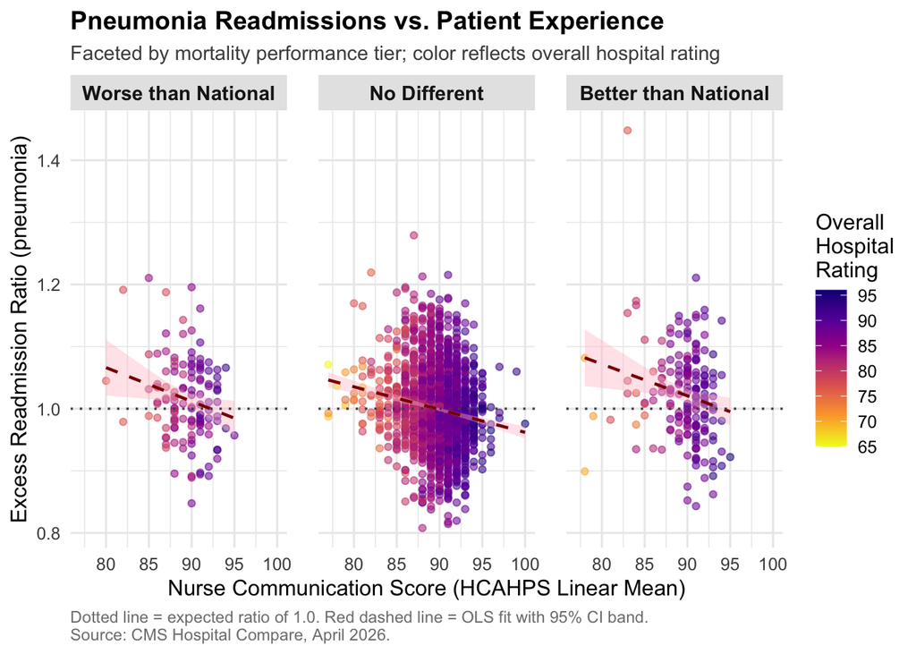

```r
# Build the plot
ggplot(plot_data,
       aes(x = `HcahpsLinearMeanValue_Nurse communication`,
           y = ExcessReadmissionRatio,
           color = `HcahpsLinearMeanValue_Overall hospital rating`)) +
    geom_point(alpha = 0.55, size = 1.5) +
    geom_smooth(method = "lm",
                se = TRUE,
                color = "darkred",
                fill = "pink",
                linetype = "dashed",
                linewidth = 0.8) +
    geom_hline(yintercept = 1.0,
               linetype = "dotted",
               color = "gray30",
               linewidth = 0.6) +
    facet_wrap(~ DeathRateCategory) +
    scale_color_viridis_c(option = "plasma", direction = -1) +
    labs(
        title    = "Pneumonia Readmissions vs. Patient Experience",
        subtitle = "Faceted by mortality performance tier; color reflects overall hospital rating",
        x        = "Nurse Communication Score (HCAHPS Linear Mean)",
        y        = "Excess Readmission Ratio (pneumonia)",
        color    = "Overall\nHospital\nRating",
        caption  = "Dotted line = expected ratio of 1.0. Red dashed line = OLS fit with 95% CI band.\nSource: CMS Hospital Compare, April 2026."
    ) +
    theme_minimal(base_size = 12) +
    theme(
        plot.title       = element_text(face = "bold", size = 14),
        plot.subtitle    = element_text(color = "gray30", size = 11),
        plot.caption     = element_text(color = "gray50", size = 9, hjust = 0),
        strip.background = element_rect(fill = "gray90", color = NA),
        strip.text       = element_text(face = "bold", size = 11),
        legend.position  = "right",
        panel.spacing    = unit(1.2, "lines")
    )
```

Lastly, make sure to **interpret** your graphic.

**Answer:**

This is multivariable storytelling: you’d be able to see whether better nurse communication correlates with lower readmissions, whether this relationship holds across mortality tiers, and whether overall rating reinforces or contradicts the pattern.

# References

De Alba, Israel, and Alpesh Amin. 2014. “Pneumonia Readmissions: Risk Factors and Implications.” *Ochsner Journal* 14 (4): 649–54.

R Core Team. 2019. *R: A Language and Environment for Statistical Computing*. R Foundation for Statistical Computing. https://www.R-project.org.

Wickham, Hadley. 2014. “Tidy Data.” *Journal of Statistical Software* 59 (10): 1–23. https://doi.org/10.18637/jss.v059.i10.